# Práctica 2. Análisis descriptivo

Ana Escoto

31/05/2021

## Consejo para escribir “código”"

En general, cuando hacemos nuestro código querremos verificar que nuestras librerías estén instaladas. Si actualizamos nuestro R y Rstudio es probable (sobre todo en MAC) que hayamos perdido alguno.

Este es un ejemplo de un código. Y vamos a introducir un paquete muy útil llamado “pacman”

```r
if (!require("pacman")) install.packages("pacman") # instala pacman si se requiere
pacman::p_load(tidyverse,
               readxl,writexl,googlesheets4, # importar hojas de cálculo
               haven, foreign, # importación de dta y sab
               sjlabelled, # etiquetas
               janitor, skimr) #carga los paquetes necesarios para esta práctica
```

# Importando más datos

Si estas desde tu escritorio *¡Recuerda establecer tu directorio!*

Pero… a veces preferimos trabajar en proyectos, sobre todo porque nos da más control. Hay gente que lo dice mejor que yo, como Hadley Wickham: https://es.r4ds.hadley.nz/flujo-de-trabajo-proyectos.html

```r
setwd("G:\\Mi unidad\\2021-II\\[AC2021]\\Taller_AC2021")
```

Hay muchos formatos de almacenamiento de bases de datos. Vamos a aprender a importar información desde ellos.

## Desde Excel

El paquete más compatible con RStudio es readxl. A veces, otros paquetes tienen más problemas de configuración entre R y el Java.

```r
ICI_2018 <- read_excel("./datos/ICI_2018.xlsx", sheet = "para_importar")
```

```
## * `` -> ...128
## * `` -> ...129
## * `` -> ...132
## * ...
```

```r
#View(ICI_2018)
```

## Desde STATA y SPSS

Si bien también se puede realizar desde el paquete foreign. Pero este no importa algunas características como las etiquetas y tampoco funciona con las versiones más nuevas de STATA. Vamos a instalar otro paquete, compatible con el mundo tidyverse.

Recuerda que no hay que instalarlo (viene adentro de tidyverse). Se instala sólo la primera vez. Una vez instalado un paquete, lo llamamos con el comando “library”

```r
lapop2019 <- read_dta("./datos/lapop2019.dta")
```

## Selección de casos y de variables

Poco a poco vamos comprendiendo más la lógica de R. Hay varias “formas” de programar. Por lo que no te asustes si varios códigos llegan al mismo resultado

Para revisar el contenido de un data frame podemos usar, como lo hicimos anteriormente, el formato basededatos$var o usar corchete, checa como estas cuatro formas tan el mismo resultado.

```r
x<-lapop2019$a4
x<-lapop2019[["a4"]]  # ¡Ojo con las comillas!
x<-lapop2019[,17]
x<-lapop2019[,"a4"]
```

Ahora, con el formato de dplyr podemos llegar a lo mismo.

Operador de “pipe” o “tubería” %>% (Ctrl+Shift+M) Antes de continuar, presentemos el operador “pipe” %>%. dplyr importa este operador de otro paquete (magrittr). Este operador le permite canalizar la salida de una función a la entrada de otra función. En lugar de funciones de anidamiento (lectura desde adentro hacia afuera), la idea de la tubería es leer las funciones de izquierda a derecha.

```r
x<-lapop2019 %>%
  select(a4)
```

## Etiquetas importadas y cómo usarlas

Podemos ver que los objetos “data.frame”(spoiler, ya hablaremos de ellos), tiene una clase que se llama “haven_labelled”

```r
class(lapop2019$q1)
```

```
## [1] "haven_labelled" "vctrs_vctr"     "double"
```

¿Esto que significa? Que en el programa original hay alguna etiqueta que podemos usar.

```r
table(lapop2019$q1)
```

```
##
##   1   2
## 775 805
```

```r
table(as_label(lapop2019$q1))
```

```
##
## Hombre  Mujer
##    775    805
```

## Selección “inversa”

O sea no “botar algo”, es con el negativo. No funciona con todos los formatos

```r
x<-lapop2019 %>%
  select(-ed)
x<-lapop2019[,-126]

rm(x) #rm sólo bota objetos
```

Pero con los otros formatos podemos “asignar” valores adentro de un data.frame, y uno de eso valores puede ser “la nada”"

```r
lapop2019$ed_2<-lapop2019$ed
lapop2019$ed_2<-NULL
```

De aquí viene esa cuesta en el aprendizaje; tenemos que comprender en qué forma programó el que hizo la librería e incluso a veces cómo aprendió quién te está enseñando o el foro que estás leyendo.

# Subsetting

Rara vez utilizamos una base de datos completa, y rara vez queremos hacer operaciones completas con ellas.

Vamos a pedir cosas más específicas y podemos seleccionar observaciones o filas. Como nuestra base de datos es muy grande, guardaremos el filtro o selección en un objeto.

```r
subset1<-lapop2019[lapop2019$ed>4,]
```

También podemos seleccionar columnas

```r
subset2<- lapop2019[, c("q1", "q2", "ed")]
```

podemos combinar los dos tipos de selección

```r
subset3<- lapop2019[(lapop2019$ed>4 & lapop2019$q1==1 ), c("q1", "q2", "ed")]
```

Con dplyr, podemos usar “filter” y “select”

```r
subset4<-lapop2019 %>%
  filter(ed>4 & q1==1) %>%
    select(q1, q2, ed)
```

# Variables nominales

La variable nominal “q1”, se captura con “1” para hombres y con un “2” para mujeres en la base de datos. Podemos establecer una operación de igual y además sumar los casos que cumplan con esta condición:

```r
lapop2019 %>% count(q1==2) # cuentan los casos que cumplen con la condición "q1==2"
```

```
## # A tibble: 2 x 2
##   `q1 == 2`     n
## * <lgl>     <int>
## 1 FALSE       775
## 2 TRUE        805
```

Esto es a lo que nos referimos con contar frecuencias. Podemos contar casos que cumplan con una operación de igualdad.

```r
lapop2019 %>% with(table(q1))
```

```
## q1
##   1   2
## 775 805
```

Con “tabyl()”" de “janitor”"

```r
lapop2019 %>% mutate(q1=as_label(q1))  %>% tabyl(q1)
```

```
##      q1   n   percent
##  Hombre 775 0.4905063
##   Mujer 805 0.5094937
```

Para ver que esto es una distribución de frecuencias sería muy útil ver la proporción total, ello se realiza agregando un elemento más en nuestro código con una “tubería”:

```r
lapop2019 %>% mutate(q1=as_label(q1))  %>% tabyl(q1) %>% adorn_totals()
```

```
##      q1    n   percent
##  Hombre  775 0.4905063
##   Mujer  805 0.5094937
##   Total 1580 1.0000000
```

Hoy revisamos algunos tipos de variables

```r
class(lapop2019$q1) # variable sin etiqueta
```

```
## [1] "haven_labelled" "vctrs_vctr"     "double"
```

```r
class(as_label(lapop2019$q1)) # variable con etiqueta
```

```
## [1] "factor"
```

```r
class(as_label(lapop2019$soct2))
```

```
## [1] "factor"
```

```r
class(as_label(lapop2019$ed))
```

```
## [1] "factor"
```

En general, tendremos variables de factor que podrían ser consideradas como cualitativas y numéricas. Aunque en realidad, R tiene muchas formas de almacenamiento. Como mostramos con el comando “glimpse()” en capítulo anterior, podemos revisar una variable en específico:

```r
glimpse(lapop2019$q1)
```

```
##  dbl+lbl [1:1580] 1, 1, 2, 1, 2, 2, 2, 2, 2, 2, 2, 1, 2, 2, 2, 1, 2, 1, 1, ...
##  @ label       : chr "Sexo"
##  @ format.stata: chr "%36.0g"
##  @ labels      : Named num [1:2] 1 2
##   ..- attr(*, "names")= chr [1:2] "Hombre" "Mujer"
```

```r
lapop2019 %>% mutate(q1=as_label(q1)) %>% # cambia los valores de la variable a sus etiquetas
                tabyl(q1) %>% # para hacer la tabla
                adorn_totals() %>% # añade totales
                adorn_pct_formatting()  # nos da porcentaje en lugar de proporción
```

```
##      q1    n percent
##  Hombre  775   49.1%
##   Mujer  805   50.9%
##   Total 1580  100.0%
```

### Variables ordinales

Son variables que dan cuenta de cualidades o condiciones a través de categorías que guardan un orden entre sí.

Vamos a darle una “ojeada” a esta variable

```r
glimpse(lapop2019$soct2)
```

```
##  dbl+lbl [1:1580] 3, 3, 1, 1, 2, 3, 3, 2, 3, 2, 3, 2, 3, 2, 1, 1, 1, 2, 2, ...
##  @ label       : chr "Evaluación de la situación económica del país"
##  @ format.stata: chr "%36.0f"
##  @ labels      : Named num [1:6] 1 2 3 NA NA NA
##   ..- attr(*, "names")= chr [1:6] "Mejor" "Igual" "Peor" "No sabe" ...
```

Hoy hacemos la tabla, con las etiquetas:

```r
lapop2019 %>% mutate(soct2=as_label(soct2)) %>%
                tabyl(soct2)
```

```
##  soct2   n    percent valid_percent
##  Mejor 364 0.23037975     0.2368250
##  Igual 718 0.45443038     0.4671438
##   Peor 455 0.28797468     0.2960312
##   <NA>  43 0.02721519            NA
```

Para que no nos salgan las categorías sin datos podemos poner una opción dentro del comando “tabyl()”

```r
lapop2019 %>%
  mutate(soct2=as_label(soct2)) %>%
                tabyl(soct2, show_missing_levels=F ) %>% # esta opción elimina los valores con 0
                adorn_totals()
```

```
##  soct2    n    percent valid_percent
##  Mejor  364 0.23037975     0.2368250
##  Igual  718 0.45443038     0.4671438
##   Peor  455 0.28797468     0.2960312
##   <NA>   43 0.02721519            NA
##  Total 1580 1.00000000     1.0000000
```

# Bivariado cualitativo

## Cálculo de frecuencias

Las tablas de doble entrada tiene su nombre porque en las columnas entran los valores de una variable categórica, y en las filas de una segunda. Basicamente es como hacer un conteo de todas las combinaciones posibles entre los valores de una variable con la otra.

Por ejemplo, si quisiéramos combinar las dos variables que ya estudiamos lo podemos hacer, con una tabla de doble entrada:

```r
lapop2019 %>%
  mutate(soct2=as_label(soct2)) %>% # para que las lea como factor
  mutate(q1=as_label(q1)) %>% # para que las lea como factor
                tabyl(soct2, q1, show_missing_levels=F ) %>% # incluimos aquí
                adorn_totals()
```

```
##  soct2 Hombre Mujer
##  Mejor    215   149
##  Igual    372   346
##   Peor    168   287
##   <NA>     20    23
##  Total    775   805
```

Observamos que en cada celda confluyen los casos que comparten las mismas características:

```r
lapop2019 %>%
    count(soct2==1 & q1==1) # nos da la segunda celda de la izquierda
```

```
## # A tibble: 3 x 2
##   `soct2 == 1 & q1 == 1`     n
## * <lgl>                  <int>
## 1 FALSE                   1345
## 2 TRUE                     215
## 3 NA                        20
```

### Totales y porcentajes

De esta manera se colocan todos los datos. Si observa al poner la función “adorn_totals()” lo agregó como una nueva fila de totales, pero también podemos pedirle que agregue una columna de totales.

```r
lapop2019 %>%
  mutate(soct2=as_label(soct2)) %>% # para que las lea como factor
  mutate(q1=as_label(q1)) %>% # para que las lea como factor
    tabyl(soct2, q1, show_missing_levels=F ) %>% # incluimos aquí q1o
                adorn_totals("col")
```

```
##  soct2 Hombre Mujer Total
##  Mejor    215   149   364
##  Igual    372   346   718
##   Peor    168   287   455
##   <NA>     20    23    43
```

O bien agregar los dos, introduciendo en el argumento “c(”col“,”row“)” un vector de caracteres de las dos opciones requeridas:

```r
lapop2019 %>%
  mutate(soct2=as_label(soct2)) %>% # para que las lea como factor
  mutate(q1=as_label(q1)) %>% # para que las lea como factor
                tabyl(soct2, q1, show_missing_levels=F ) %>% # incluimos aquí q1o
                adorn_totals(c("col", "row"))
```

```
##  soct2 Hombre Mujer Total
##  Mejor    215   149   364
##  Igual    372   346   718
##   Peor    168   287   455
##   <NA>     20    23    43
##  Total    775   805  1580
```

Del mismo modo, podemos calcular los porcentajes. Pero los podemos calcular de tres formas. Uno es que lo calculemos para los totales calculados para las filas, para las columnas o para el gran total poblacional.

Para columnas tenemos el siguiente código y los siguientes resultados:

```r
lapop2019 %>%
  mutate(soct2=as_label(soct2)) %>% # para que las lea como factor
  mutate(q1=as_label(q1)) %>% # para que las lea como factor
  tabyl(soct2, q1, show_missing_levels=F ) %>% # incluimos aquí sexo
                adorn_totals(c("col", "row")) %>%
                adorn_percentages("col") %>% # Divide los valores entre el total de la columna
                adorn_pct_formatting() # lo vuelve porcentaje
```

```
##  soct2 Hombre  Mujer  Total
##  Mejor  27.7%  18.5%  23.0%
##  Igual  48.0%  43.0%  45.4%
##   Peor  21.7%  35.7%  28.8%
##   <NA>   2.6%   2.9%   2.7%
##  Total 100.0% 100.0% 100.0%
```

Cuando se hagan cuadros de distribuciones (que todas sus partes suman 100), los porcentajes pueden ser una gran ayuda para la interpretación, sobre todos cuando se comparar poblaciones de categorías de diferente tamaño. Por lo general, queremos que los cuadros nos den información de donde están los totales y su 100%, de esta manera el lector se puede guiar de porcentaje con respecto a qué está leyendo. En este caso, vemos que el 100% es común en la última fila.

```r
lapop2019 %>%
  mutate(soct2=as_label(soct2)) %>% # para que las lea como factor
  mutate(q1=as_label(q1)) %>% # para que las lea como factor
                tabyl(ed, q1, show_missing_levels=F ) %>%
                adorn_totals(c("col", "row")) %>%
                adorn_percentages("row") %>% # Divide los valores entre el total de la fila
                adorn_pct_formatting() # lo vuelve porcentaje
```

```
##     ed Hombre  Mujer  Total
##      0  45.7%  54.3% 100.0%
##      1  36.8%  63.2% 100.0%
##      2  37.9%  62.1% 100.0%
##      3  51.0%  49.0% 100.0%
##      4  43.5%  56.5% 100.0%
##      5  60.7%  39.3% 100.0%
##      6  48.9%  51.1% 100.0%
##      7  76.9%  23.1% 100.0%
##      8  55.3%  44.7% 100.0%
##      9  41.7%  58.3% 100.0%
##     10  50.0%  50.0% 100.0%
##     11  51.8%  48.2% 100.0%
##     12  51.7%  48.3% 100.0%
##     13  58.8%  41.2% 100.0%
##     14  56.2%  43.8% 100.0%
##     15  51.7%  48.3% 100.0%
##     16  44.4%  55.6% 100.0%
##     17  77.4%  22.6% 100.0%
##     18  53.9%  46.1% 100.0%
##   <NA>   0.0% 100.0% 100.0%
##  Total  49.1%  50.9% 100.0%
```

Finalmente, podemos calcular los porcentajes con referencia a la población total en análisis. Es decir la celda en la esquina inferior derecha de nuestra tabla original.

```r
lapop2019 %>%
  mutate(soct2=as_label(soct2)) %>% # para que las lea como factor
  mutate(q1=as_label(q1)) %>% # para que las lea como factor
                tabyl(soct2, q1, show_missing_levels=F ) %>% # incluimos aquí q1o
                adorn_totals(c("col", "row")) %>%
                adorn_percentages("all") %>% # Divide los valores entre el total de la población
                adorn_pct_formatting() # lo vuelve porcentaje
```

```
##  soct2 Hombre Mujer  Total
##  Mejor  13.6%  9.4%  23.0%
##  Igual  23.5% 21.9%  45.4%
##   Peor  10.6% 18.2%  28.8%
##   <NA>   1.3%  1.5%   2.7%
##  Total  49.1% 50.9% 100.0%
```

# Descriptivos para variables cuantitativas

Vamos a empezar a revisar los gráficos para variables cuantitativas.

## Medidas numéricas básicas

5 números

```r
summary(lapop2019$ed) ## educación
```

```
##    Min. 1st Qu.  Median    Mean 3rd Qu.    Max.    NA's
##   0.000   6.000   9.000   9.846  12.000  18.000      12
```

Con pipes se pueden crear “indicadores” de nuestras variables es un tibble

```r
lapop2019 %>%
  summarise(nombre_indicador=mean(ed, na.rm=T))
```

```
## # A tibble: 1 x 1
##   nombre_indicador
##              <dbl>
## 1             9.85
```

## Histograma básico

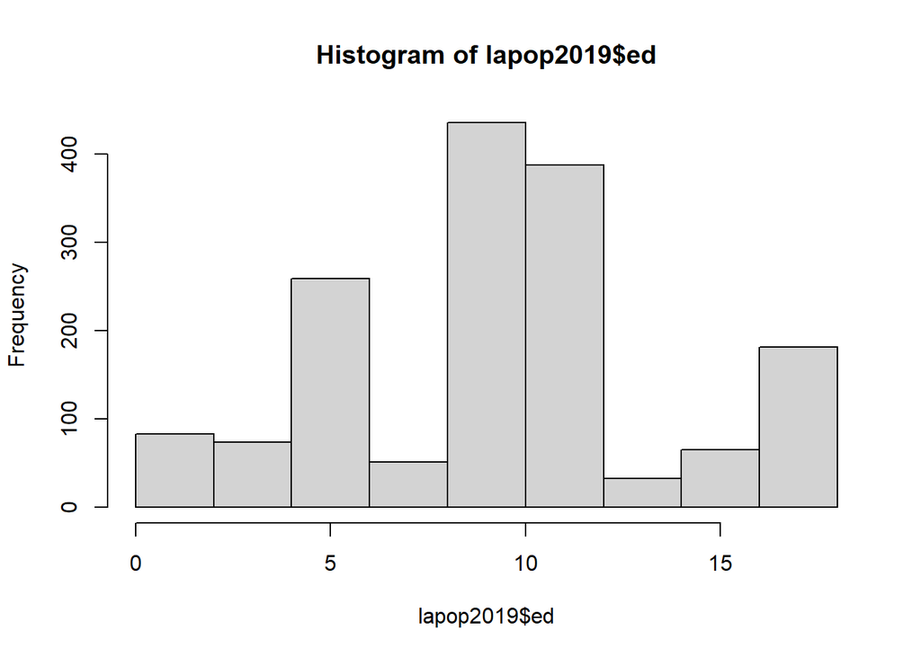

```r
hist(lapop2019$ed)
```

Le podemos modificar el título del eje de las x y de las y

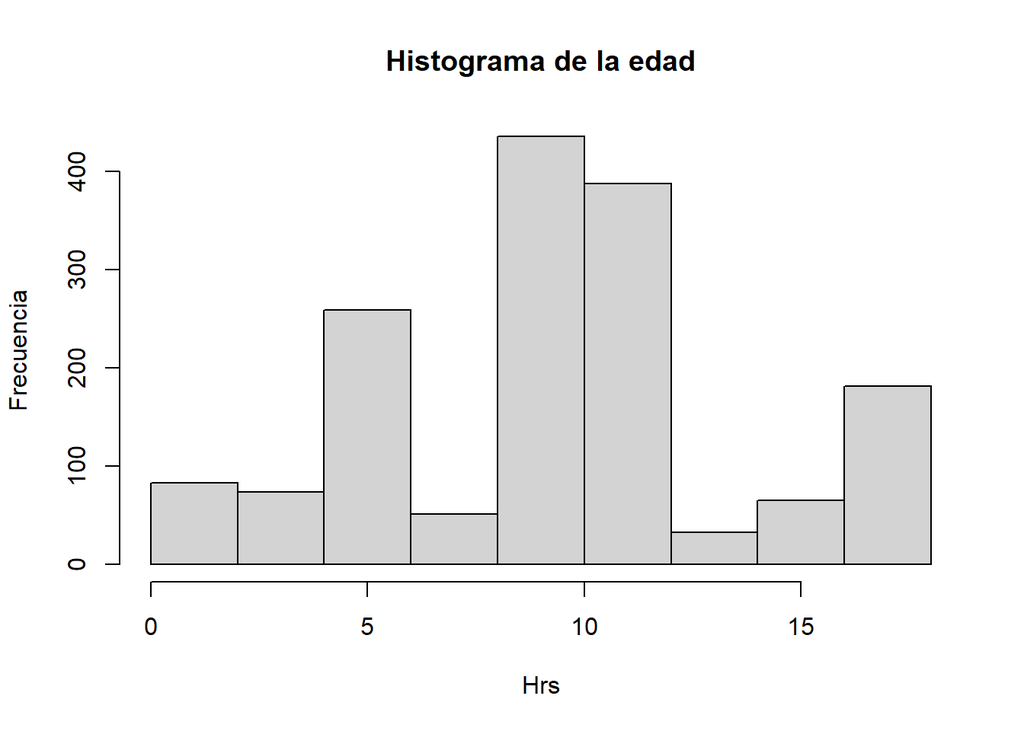

```r
hist(lapop2019$ed,
     main="Histograma de la edad",
     xlab="Hrs", ylab="Frecuencia")
```

¡A ponerle colorcitos! Aquí hay una lista http://www.stat.columbia.edu/~tzheng/files/Rcolor.pdf

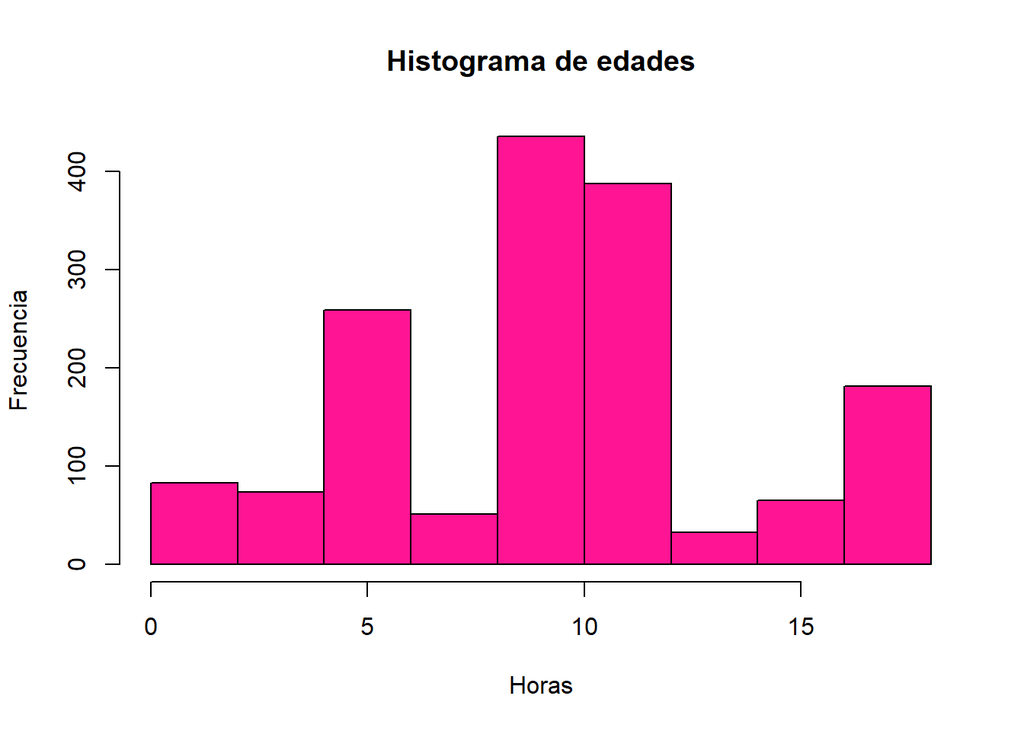

```r
hist(lapop2019$ed,
     main="Histograma de edades",
     xlab="Horas",
     ylab="Frecuencia", col="deeppink1")
```

## con pipes

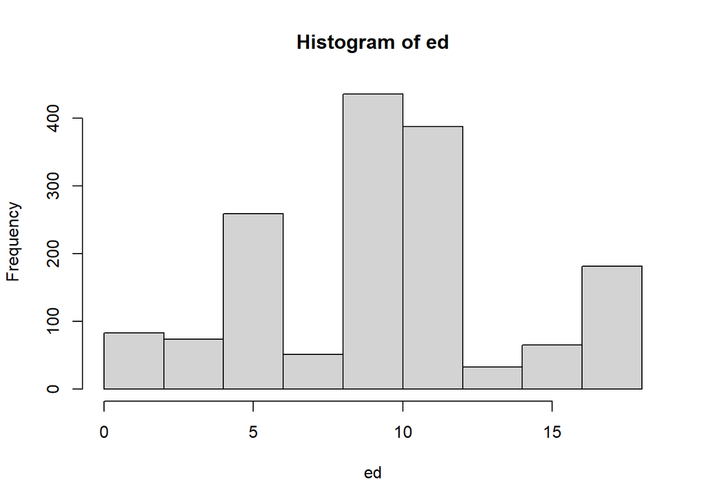

```r
lapop2019 %>%
    with(hist(ed)) # con with, para que entienda
```

Cuando usamos pipes, se debe de recordar que no es necesario escribir el nombre del data.frame en el filtro porque es lo primero que colocamos en nuestro “pipe”.

Checa que cualquier aditamiento debe ir en el pipe donde está el comando de hist(). Ten cuidado con los paréntesis.

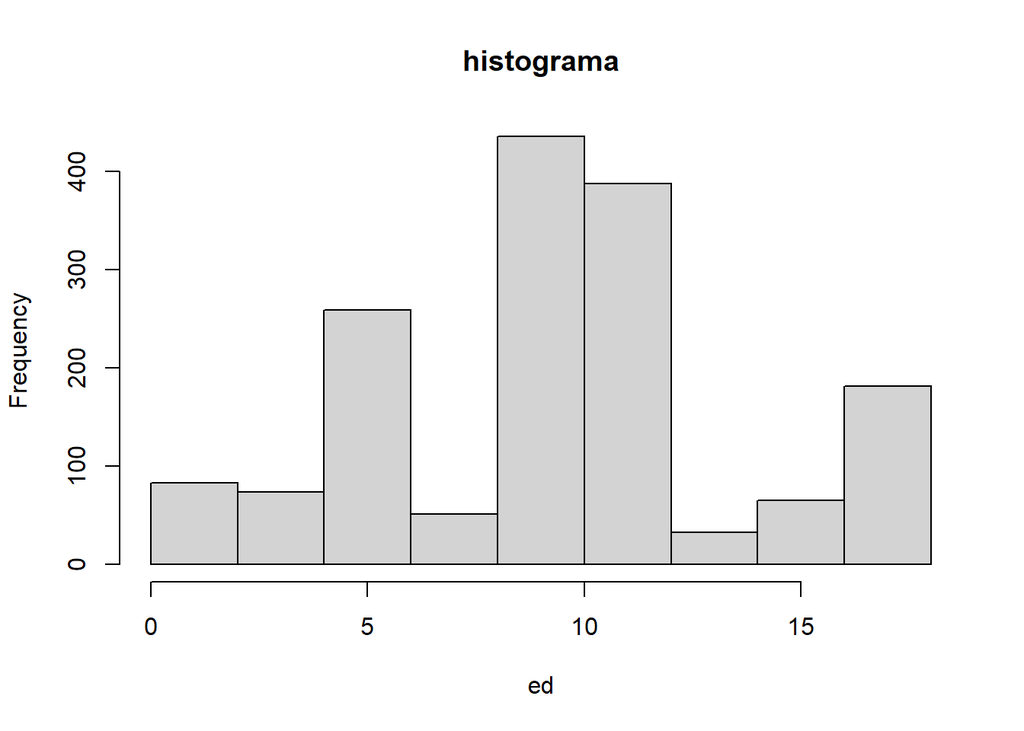

```r
lapop2019 %>%
  filter(!is.na(ed)) %>% # la ventaja de esta forma es que podemos hacer más operaciones
    with(hist(ed, main= "histograma"))
```